# Wafer analysis

# Wafer explanation

```r
wafers <- read.xlsx('wafers.xlsx',colClasses = NA,sheetIndex=2)
wafers$WaferID <- paste(wafers$Ruffle,wafers$Depth,sep='')
wafers$WaferID <- as.factor(wafers$WaferID)
levels(wafers$WaferID) <- c('0.00','0.05','20.025','20.05','50.025','50.05','70.025','70.05')
with(wafers,{table(Treatment,Finish,Liquid)})
```

```
## , , Liquid = plasma
##
##                Finish
## Treatment       glossy matte  pp
##   clean              7    10   0
##   paa.10min          0     0   0
##   paa.30min          0     0   0
##   paa.5min           0     0   0
##   peo-meoh-0.4       0     0   0
##   peo-meoh-3.4       0     0   0
##   peo-w              0     0   0
##   plasma.coated      7     0   0
##   support            0     7   0
##   wash1              0     7   0
##
## , , Liquid = water
##
##                Finish
## Treatment       glossy matte  pp
##   clean             52     0   6
##   paa.10min          6     0   0
##   paa.30min          7     0   0
##   paa.5min           6     0   0
##   peo-meoh-0.4     150     0   4
##   peo-meoh-3.4      47     0   4
##   peo-w             32     0   0
##   plasma.coated      7     0   0
##   support            0     0   0
##   wash1              0     0   0
```

```r
wafers$TreatmentType <- wafers$Treatment
levels(wafers$TreatmentType) <- list(paa=c("paa.10min","paa.30min","paa.5min"),
                                     peo=c("peo-meoh-0.4","peo-meoh-3.4","peo-w"),
                                     plasma=c("plasma.coated"),
                                     support=c('support','wash1'),
                                     clean='clean')
```

## Poly(ethylene oxide) coatings

I coated the wafers with poly(ethylene oxide) (a.k.a. poly(ethylene glycol)) with a $M_v = 100000$ to see if a coating would increase the hydrophilicity of the weir and encourage flowdown. I coated the wafers with PEO dissolved separately in water (wt% unknown) and in methanol ($0.4% and 3.4 wt%$). (The plots of peo-water are not displayed here. see code.)

#### Procedure

1. coated the wafer with a polymer solution and let it dry (10 min - 2 hours).
2. I placed 250 $\mu L$ water in the headspace of the wafer and caused the liquid to barely wet the ruffles using my pipet tip. I slowly tilted the wafer for the liquid to flow down the ruffles and measured the angle at which the liquid front moved at a constant rate.
3. After the angle was measured, I used the side of the pipet tip to spread the water over all un-wetted regions of the wafer.
4. I let the water sit for at least 10s.
5. Then, the water was blown off the wafer using compressed air for at least 30s.

Rolldown angles for each run wafer and run are shown below. A graph summarizing the overall results is shown below that one.

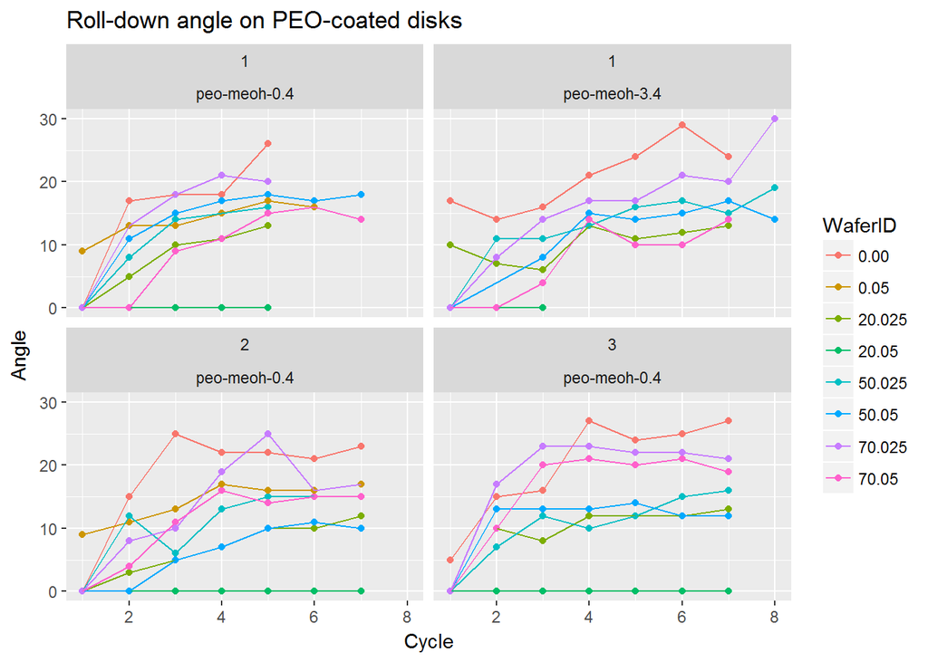

```r
PEOmeoh <- wafers[grepl('meoh',wafers$Treatment) &
                    wafers$Finish=='glossy',]

ggplot(PEOmeoh,aes(x=Cycle,y=Angle,color=WaferID))+
  geom_point()+
  geom_line()+
  facet_wrap(Replicate~Treatment,ncol=2)+
  ggtitle('Roll-down angle on PEO-coated disks')
```

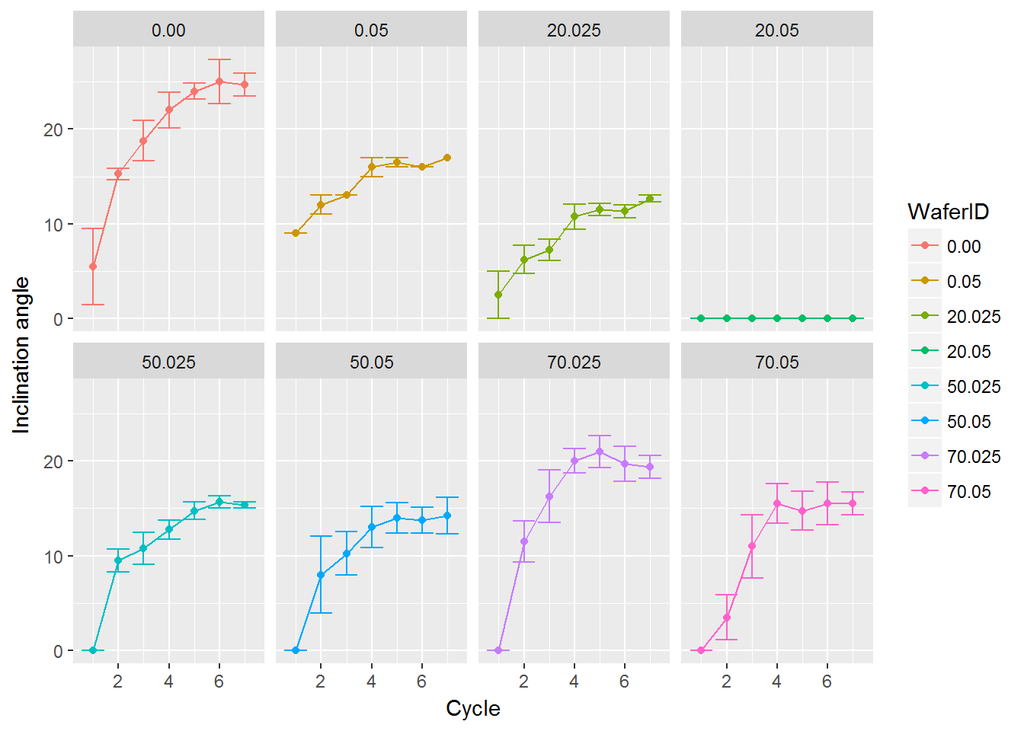

```r
PEOsum <- PEOmeoh[PEOmeoh$Cycle<8,] %>% group_by(WaferID,Cycle) %>% summarise(n=n(),mean = mean(Angle),sd = sd(Angle),se=sd/sqrt(n))

ggplot(PEOsum,aes(Cycle,mean,color=WaferID))+
  geom_point()+
  geom_line()+
  geom_errorbar(aes(ymin=mean-se,ymax=mean+se),na.rm=TRUE)+
  facet_wrap(~WaferID,ncol=4)+
  ylab('Inclination angle')+ggsave('PEO_coating_summary.png')
```

## Ruffle dimensions

Instead of looking at the angles and depth, I’ll look at the peak-to-peak distance and the cross-sectional area of the ruffles because those factors should affect the liquid directly. A table is shown below with the distance between ruffle peaks in centimeters.

```r
wafers$PeakDist <- 2*wafers$Depth*tan(wafers$Ruffle*3.1415/180)*2.54
# have to include this as a factor because 0.00 and 0.05 have the same peak distance
PeakDistf <- c(0.000,0.000,0.046,0.092,0.151,0.302,0.348,0.698)


wafers$TroughPerim <- 2*wafers$Depth/cos(wafers$Ruffle*3.14159/180)*2.54
wafers[wafers$TroughPerim == 0.254,]$TroughPerim <- 0
TroughPerimf <- as.numeric(c(0,levels(as.factor(wafers$TroughPerim))))

data.frame(waferID=levels(wafers$WaferID),'W/2d'=PeakDistf/TroughPerimf)
```

```
##   waferID      W.2d
## 1    0.00       NaN
## 2    0.05       NaN
## 3  20.025 0.3403611
## 4   20.05 0.4656418
## 5  50.025 0.5586362
## 6   50.05 0.8133100
## 7  70.025 0.8806704
## 8   70.05 0.9398848
```

```r
RuffleType <- data.frame(ID=levels(wafers$WaferID),PeakDistance_cm=PeakDistf)
RuffleType
```

```
##       ID PeakDistance_cm
## 1   0.00           0.000
## 2   0.05           0.000
## 3 20.025           0.046
## 4  20.05           0.092
## 5 50.025           0.151
## 6  50.05           0.302
## 7 70.025           0.348
## 8  70.05           0.698
```

The distance between ruffles is less than a millimeter for the 20 degree wafers. For 50 and 70 $^{\circ}$s, The peak distance steadily increases.

## Capillary length calculations:

The formula for capillary length is $\lambda = \sqrt{\frac{\gamma_{LV}}{\rho g}}$ where $\gamma_{LV}$ and $\rho$ are the surface tension and density of the liquid, and $g$ is the gravitational constant. The capillary length for plasma is approximately $0.21 cm$.

The 20 $^{\circ}$ ruffles wick the liquid into the channels because they are smaller than the capillary length.

### Statistical tests

I want to see if the ruffle depth really affects the angle for a clean surface

```r
clean <- subset(wafers,Finish=='glossy'&Liquid=='water'&Depth!=0 & Treatment=='clean')
clean.aov <- aov(Angle ~ Depth, data=clean)
summary(clean.aov)
```

```
##             Df Sum Sq Mean Sq F value   Pr(>F)
## Depth        1  129.2  129.18   16.98 0.000179 ***
## Residuals   41  311.9    7.61
## ---
## Signif. codes:  0 '***' 0.001 '**' 0.01 '*' 0.05 '.' 0.1 ' ' 1
```

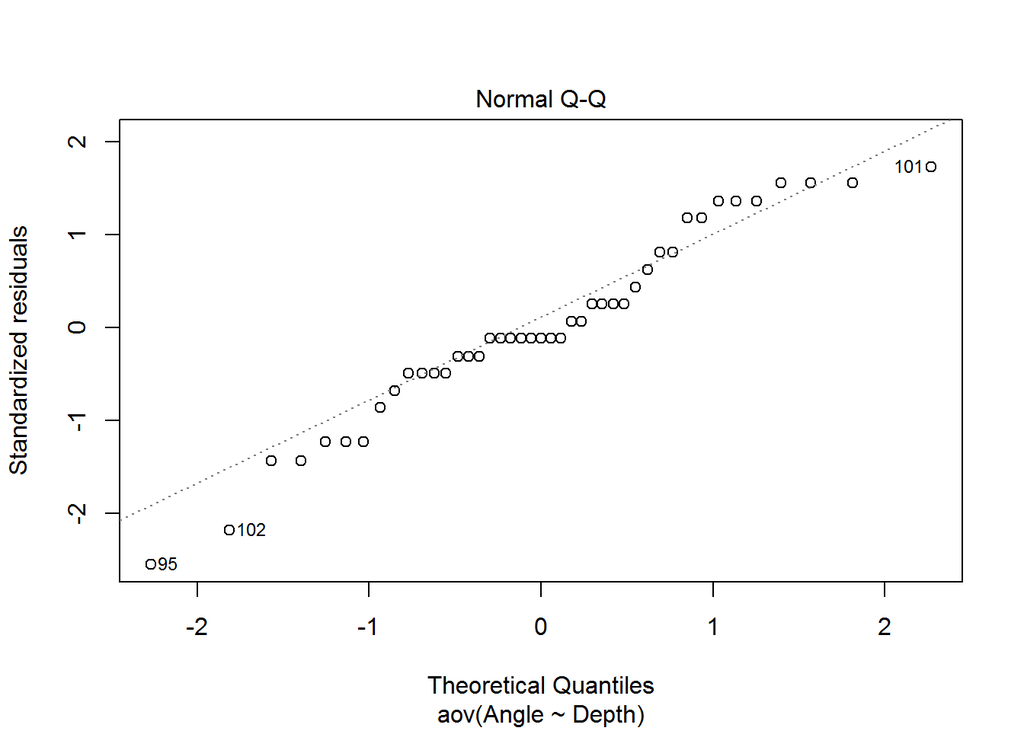

```r
plot(clean.aov,2)
```

```r
table(clean$Ruffle,clean$Depth)
```

```
##
##      0.025 0.05
##   0      0    5
##   20     6    6
##   50     6    6
##   70     6    8
```

```r
with(clean,{
  pairwise.t.test(Angle,Depth,alternative='less')})
```

```
##
##  Pairwise comparisons using t tests with pooled SD
##
## data:  Angle and Depth
##
##      0.025
## 0.05 9e-05
##
## P value adjustment method: holm
```

```r
means <- group_by(wafers,Depth + Ruffle) %>%
  summarize(.,count=n(),angle=mean(Angle),se = sd(Angle)/sqrt(count))
means
```

```
## # A tibble: 8 x 4
##   `Depth + Ruffle` count angle    se
##              <dbl> <int> <dbl> <dbl>
## 1             0       62 18.5  1.11
## 2             0.05    18 14.4  0.616
## 3            20.0     45 12.7  1.16
## 4            20.0     44  3.77 1.17
## 5            50.0     47 13.5  1.17
## 6            50.0     48 12.6  1.10
## 7            70.0     47 16.5  1.24
## 8            70.0     48 12.1  1.03
```

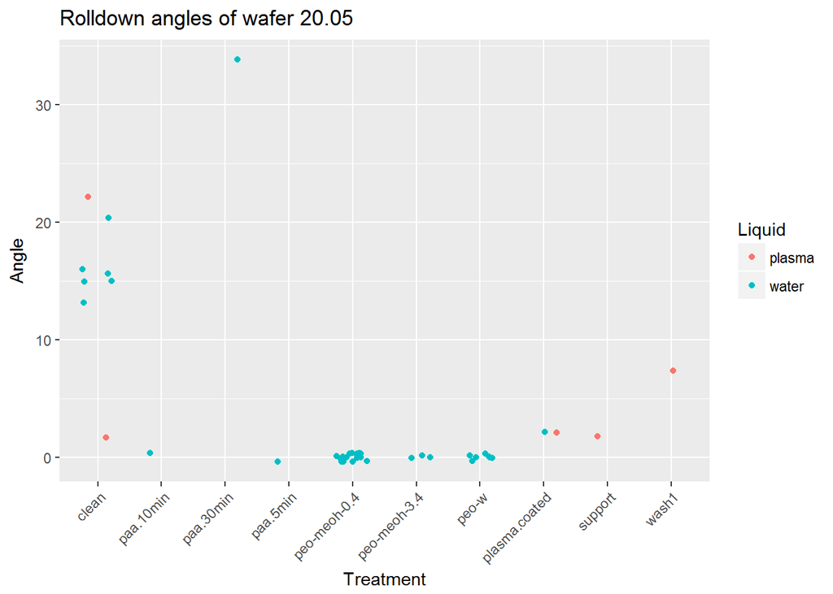

```r
Wafer20.05 <- wafers[wafers$Ruffle==20 & wafers$Depth==0.05,]
ggplot(Wafer20.05,aes(Treatment,Angle,color=Liquid))+
  geom_jitter(width=0.25)+
  ggtitle('Rolldown angles of wafer 20.05')+
  theme(axis.text.x=element_text(angle=45,hjust=1))
```